# Zoning Protected areas for Marine Species

## Overview

Marine aquaculture has the potential to play an important role in the global food supply as a more sustainable protein option than land-based meat production.[^1] [Gentry et al.](https://www.nature.com/articles/s41559-017-0257-9) mapped the potential for marine aquaculture globally based on multiple constraints, including ship traffic, dissolved oxygen, bottom depth .[^2]

In this project,I will determine which Exclusive Economic Zones (EEZ) on the West Coast of the US are best suited to developing marine aquaculture for several species of oysters.

Based on previous research, oysters needs the following conditions for optimal growth:

- sea surface temperature: 11-30°C
- depth: 0-70 meters below sea level

### Data

#### Sea Surface Temperature

Use average annual sea surface temperature (SST) from the years 2008 to 2012 to characterize the average sea surface temperature within the region. The data we are working with was originally generated from [NOAA’s 5km Daily Global Satellite Sea Surface Temperature Anomaly v3.1](https://coralreefwatch.noaa.gov/product/5km/index_5km_ssta.php).

#### Bathymetry

To characterize the depth of the ocean we will use the [General Bathymetric Chart of the Oceans (GEBCO)](https://www.gebco.net/data_and_products/gridded_bathymetry_data/#area).[^3]

#### Exclusive Economic Zones

Designate maritime boundaries using Exclusive Economic Zones off of the west coast of US from [Marineregions.org](https://www.marineregions.org/eez.php).

### Prepare data

To start, load all necessary data

- load necessary packages and set path
- read in the shapefile for the West Coast EEZ (`wc_regions_clean.shp`)
- read in SST rasters
  - `average_annual_sst_2008.tif`
  - `average_annual_sst_2009.tif`
  - `average_annual_sst_2010.tif`
  - `average_annual_sst_2011.tif`
  - `average_annual_sst_2012.tif`
- combine SST rasters into a raster stack
- read in bathymetry raster (`depth.tif`)
- check that data are in the same coordinate reference system
  - reproject any data not in the same projection

```r
#load required packages
library(stars)
library(terra)
library(tidyverse)
library(tmap)
library(patchwork)
library(ggspatial)
library(raster)
library(here)

##read the data
depth_ocean <- rast(here("data", "data", "depth.tif"))

##stack the multiple temperature rasters into on
year_2008 <- rast("data/data/average_annual_sst_2008.tif")
year_2009 <- rast("data/data/average_annual_sst_2009.tif")
year_2010 <- rast("data/data/average_annual_sst_2010.tif")
year_2011 <- rast("data/data/average_annual_sst_2011.tif")
year_2012 <- rast("data/data/average_annual_sst_2012.tif")

#stack all these SST data
temperature <- stack(c(year_2008, year_2009, year_2010, year_2011, year_2012))

##economic region data
west_coast_shape <- st_read("data/data/wc_regions_clean.shp")
```

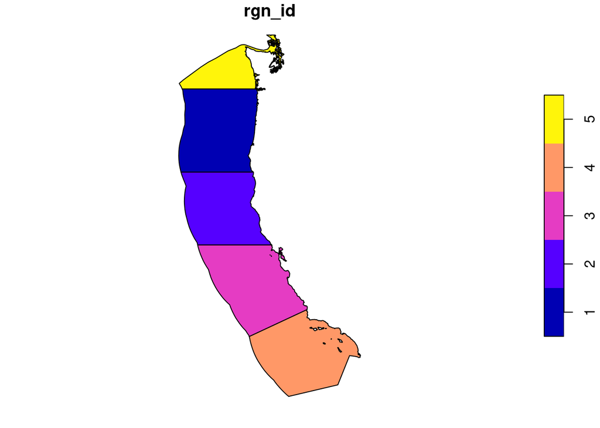

```r
plot(west_coast_shape['rgn_id'])
```

#### Process data

Process the SST and depth data so that they can be combined. In this case the SST and depth data have slightly different resolutions, extents, and positions. So, don’t change the underlying depth data. Follow the flowchart below:

- find the mean SST from 2008-2012
- convert SST data from Kelvin to Celsius
  - hint: subtract by 273.15
- crop depth raster to match the extent of the SST raster
- note: the resolutions of the SST and depth data do not match
  - resample the NPP data to match the resolution of the SST data using the nearest neighbor approach
- check that the depth and SST match in resolution, extent, and coordinate reference system
  - hint: can the rasters be stacked?

```r
#average SST between 2008 and 2012
SST_temperature <- mean(year_2008, year_2009, year_2010, year_2011, year_2012)

#convert to Celsius
SST_temperature <- SST_temperature - 273.15

##match the extent of Depth and SST(change SST to match Depth)
#1. make the crs same for both of them

SST_temperature <- project(SST_temperature, crs(depth_ocean))
crs(SST_temperature)==crs(depth_ocean)
```

```
## [1] TRUE
```

```r
#crop the Depth to match SST
cropped_depth_ocean <- crop(depth_ocean, SST_temperature)

#resample to match the resolution
cropped_depth_ocean = resample(cropped_depth_ocean, y = SST_temperature, method = "near")  ##Minimum and maximum values are out of range
```

#### Find suitable locations

In order to find suitable locations for marine aquaculture, find locations that are suitable in terms of both SST and depth.

- reclassify SST and depth data into locations that are suitable for Lump sucker fish  
  # set suitable values to `1` and unsuitable values to `NA`
- find locations that satisfy both SST and depth conditions  
  # create an overlay using the `lapp()` function multiplying cell values

```r
##reclassify SST
reclass_matrix_sst <- matrix(c(-50, 10, NA, 11, 30, 1, 31, Inf, NA), ncol = 3, byrow = TRUE)
sst_classified <- classify(SST_temperature, rcl = reclass_matrix_sst)

## reclassify Depth
cropped_depth_ocean[is.na(cropped_depth_ocean)] <- 0
reclass_matrix <- matrix(c(-10000, -71, NA, -70, 0, 1, 1, Inf, NA), ncol = 3, byrow = TRUE)
ocean_classified <- classify(cropped_depth_ocean, rcl = reclass_matrix)

##perform multiplication between two layers using lapp to create suitable areas
## stack them to check if they works
crs(sst_classified)==crs(ocean_classified)
```

```
## [1] TRUE
```

```r
#stack them
ocean_sst_stacked = stack(x= c(sst_classified, ocean_classified))
class(rast(ocean_sst_stacked))
```

```
## [1] "SpatRaster"
## attr(,"package")
## [1] "terra"
```

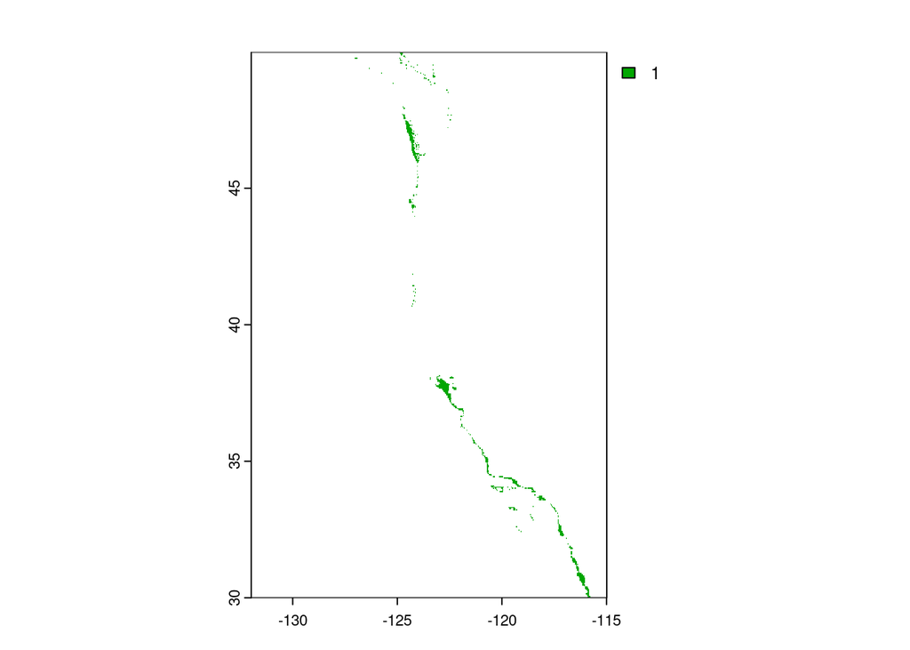

```r
##function for stacking
and_logic <- function(x, y){
  ifelse(x == 1 & y == 1, 1, NA)
}

# use local function to operate on each cells
suitable_for_sucker_fish <- terra::lapp(rast(ocean_sst_stacked), fun = and_logic)
plot(suitable_for_sucker_fish)
```

#### Determine the most suitable EEZ

Determine the total suitable area within each EEZ in order to rank zones by priority. To do so,find the total area of suitable locations within each EEZ.

- select suitable cells within West Coast EEZs
- find area of grid cells
- find the total suitable area within each EEZ
  - helpful to rasterize the EEZ data
- find the percentage of each zone that is suitable
  - helpful to join the suitable area by region onto the EEZ vector data

```r
#create dummy variable for operation
v =  west_coast_shape  #shape file
r = suitable_for_sucker_fish ## raster data

##since lat lon does not measure, projecting it to another for length measurement
target_crs <- "+proj=utm +zone=33 +datum=WGS84 +units=m +no_defs"
r_transformed <- project(r, target_crs)

#resolution on both x and y side, as multplication of them gives area
x = terra:: res(r_transformed)[1]
y = terra:: res(r_transformed)[2]

## extract all points that fall within in the EEZ shape file, and if raster value layers has NA, drop them
eez_zone = terra::extract(r, v) %>%
           na.omit()

##calcluate area under each group ID and divide it by 10**6 to convert it to Kilimoeter square.
areas_under_each_zone <- eez_zone %>%
                         group_by(ID) %>%
                         count() %>%
                         mutate(area = (n * x * y)/10^6)

##percentage of each zone that is suitable for zoning
combined_v_areas_under <- inner_join(v, areas_under_each_zone, by  = c('rgn_id'='ID')) %>%
                          group_by('rgn_id') %>%
                          mutate(percentage_of_area = area/area_km2 * 100) %>%
                          ungroup()

# percentage of area suitable for EEZ
combined_v_areas_under[c('rgn', 'percentage_of_area')]
```

```
## Simple feature collection with 5 features and 2 fields
## Geometry type: MULTIPOLYGON
## Dimension:     XY
## Bounding box:  xmin: -129.1635 ymin: 30.542 xmax: -117.097 ymax: 49.00031
## Geodetic CRS:  WGS 84
## # A tibble: 5 × 3
##   rgn                 percentage_of_area                                geometry
##   <chr>                            <dbl>                      <MULTIPOLYGON [°]>
## 1 Oregon                           0.963 (((-123.4318 46.23363, -123.4321 46.23…
## 2 Northern California              0.148 (((-124.2102 41.99843, -124.2099 41.99…
## 3 Central California               2.86  (((-122.9928 38.28022, -122.9926 38.27…
## 4 Southern California              2.32  (((-120.6505 34.97431, -120.6502 34.97…
## 5 Washington                       5.91  (((-122.7675 49.00031, -122.7603 48.99…
```

#### Visualize results

Visualize the output using basemaps:

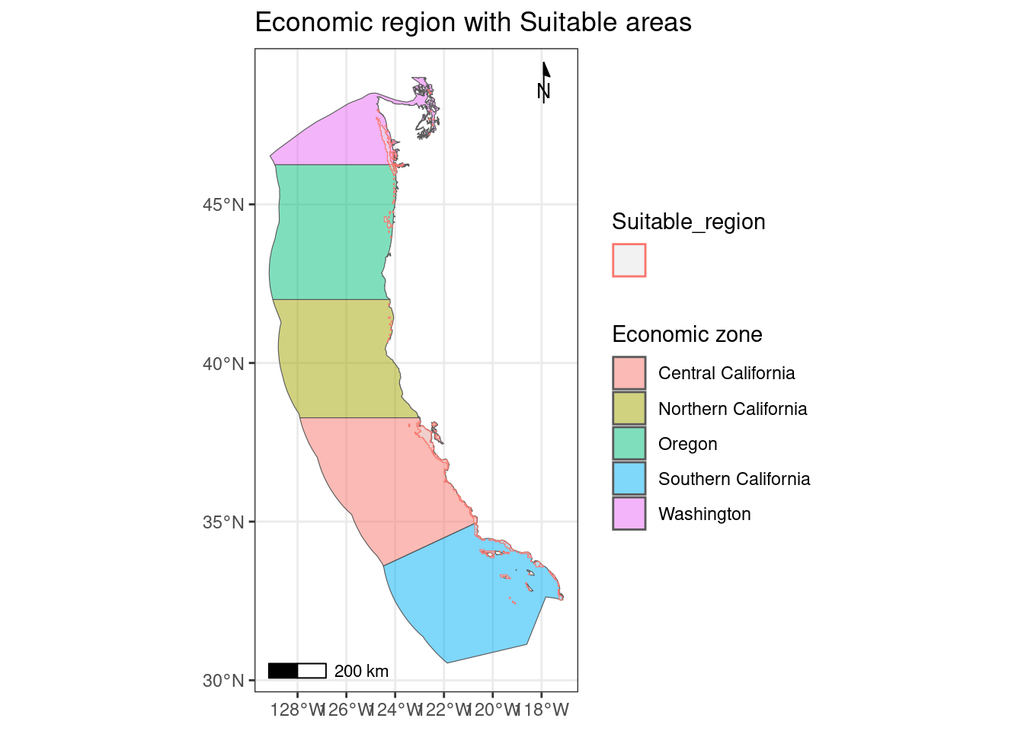

```r
#prepare the necessary class of the data
cliped_points <- as.polygons(suitable_for_sucker_fish) %>%
                     st_as_sf()

##clip the area nad make it ready for maps
cliped_points <- st_intersection(cliped_points, combined_v_areas_under)
cliped_points["Suitable_region"] <- ""

## plot the suitable regions within each eez
economic_zone <- ggplot(combined_v_areas_under)+
  geom_sf(aes(fill = rgn), alpha = 0.5)+
  labs(fill = "Economic zone")+
  annotation_scale()+
  ggtitle(as.character("Economic region with Suitable areas"))+
  annotation_north_arrow( location = "tr",
                          height = unit(0.7, "cm"),
                          width  = unit(0.7, "cm"),
                          style = north_arrow_minimal())
economic_zone +
  geom_sf(data = cliped_points, aes(color = Suitable_region), shape = 20, alpha = 0.5) +
  theme_bw()
```

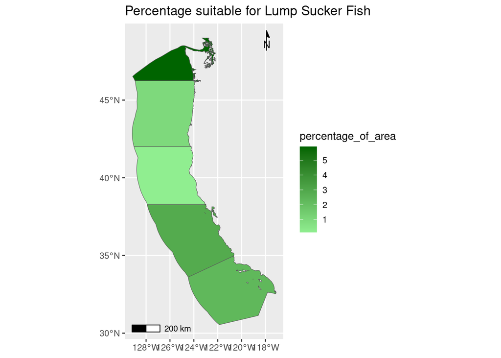

```r
## plot percent suitable area by region by block
ggplot(combined_v_areas_under)+
  geom_sf(aes(fill = percentage_of_area))+
  scale_fill_continuous(low="lightgreen", high = "darkgreen")+
  ggtitle(as.character("Percentage suitable for Lump Sucker Fish"))+
  annotation_scale()+
  annotation_north_arrow( location = "tr",
                          height = unit(0.7, "cm"),
                          width  = unit(0.7, "cm"),
                          style = north_arrow_minimal())
```

```r
##wit basemaps
invisible(suppressMessages({
  us_geo <- tigris::states(class = "sf")
}))
```

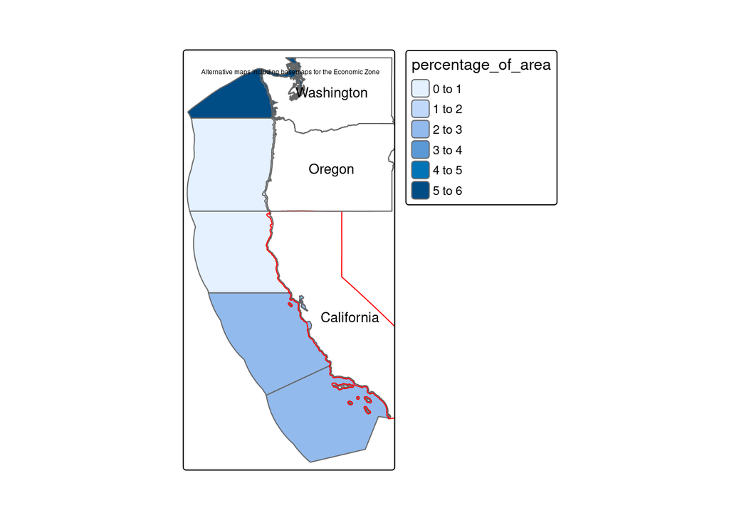

```r
california <- us_geo %>% filter(NAME == 'California')
oregon <- us_geo %>% filter(NAME == "Oregon")
washington <- us_geo %>% filter(NAME == "Washington")


tm_shape(combined_v_areas_under)+
  tm_polygons(fill = 'percentage_of_area')+
  tm_shape(california)+
  tm_text("California", size = 0.8, col = "black", bg.col = "white")+
  tm_borders(col = 'red')+
  tm_shape(oregon)+
  tm_text("Oregon", size = 0.8, col = "black", bg.col = "white")+
  tm_borders()+
  tm_shape(washington)+
  tm_text("Washington", size = 0.8, col = "black", bg.col = "white")+
  tm_borders()+
  tm_layout(title = "Alternative maps including basemaps for the Economic Zone")
```

#### Broaden the workflow: make it reproducible for any other fish in the region

Run the function for a species of your choice! You can find information on species depth and temperature requirements on [SeaLifeBase](https://www.sealifebase.ca/search.php)

```
## [1] 318.8414
```

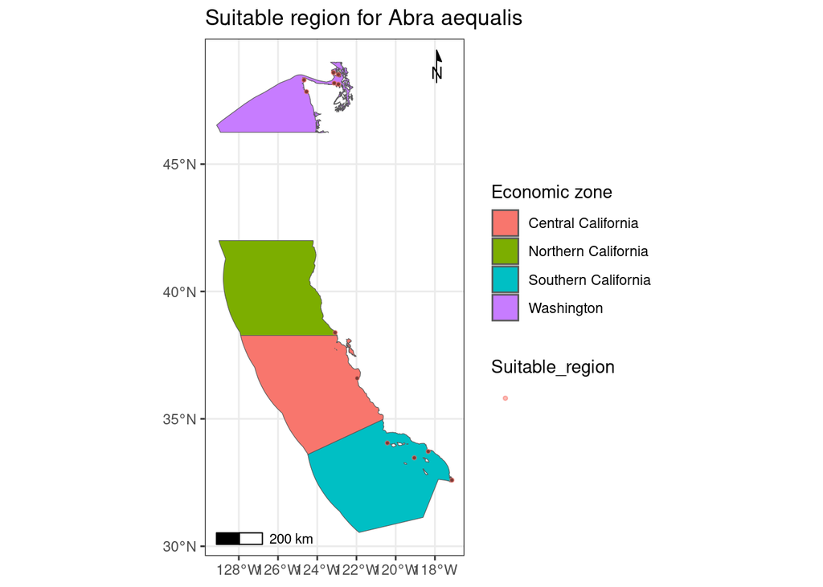

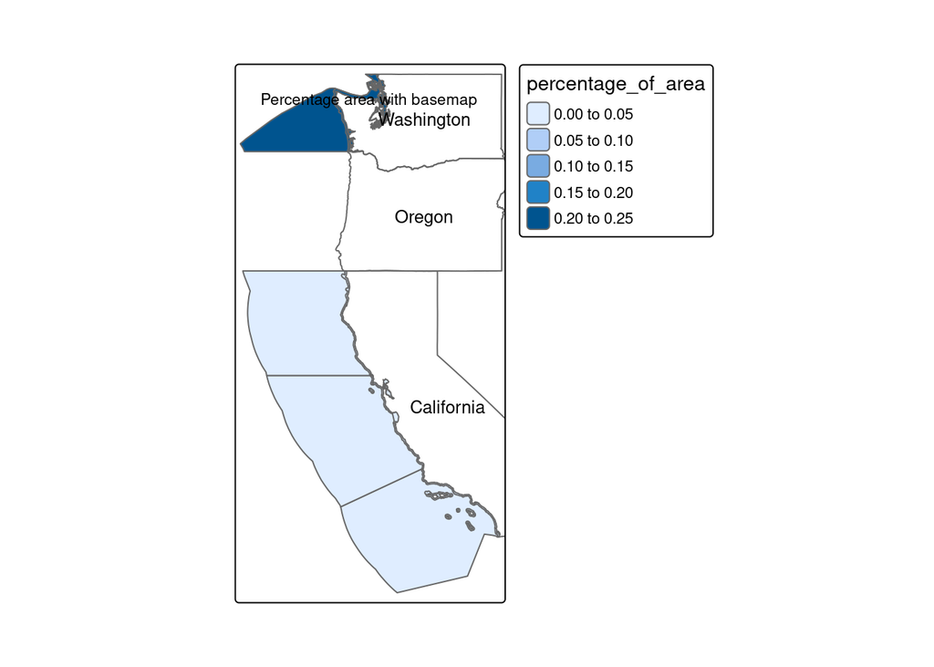

```r
##write whole function out on this
economic_zone_finder <- function(min_temp  =  min_temp,
                                 max_temp  =  max_temp,
                                 min_depth =  min_depth,
                                 max_depth =  max_depth,
                                 fish_species = fish){

depth_ocean <- rast(here("data", "data", "depth.tif"))  #read depth data
##stack the multiple temperature rasters
year_1 <- rast("data/data/average_annual_sst_2008.tif")
year_2 <- rast("data/data/average_annual_sst_2009.tif")
year_3 <- rast("data/data/average_annual_sst_2010.tif")
year_4 <- rast("data/data/average_annual_sst_2011.tif")
year_5 <- rast("data/data/average_annual_sst_2012.tif")

#perform data manipulation
temperature_stacked  <-   stack(c(year_1, year_2, year_3, year_4, year_5))
west_coast           <-   st_read("data/data/wc_regions_clean.shp")
sst_temperature      <-   rast(mean(temperature_stacked) - 273.15)  #(find mean among year and convert to celsius)

##match the extent of Depth and SST(change SST to match Depth)
#check if the crs is same

sst_temperature <- project(sst_temperature, crs(depth_ocean))


##match the extent and origin of surface temperature and ocen depth and resample
cropped_depth_ocean <- resample(crop(depth_ocean, sst_temperature),
                                       y = sst_temperature, method = 'near')

##reclassify surface temperatue
reclass_matrix_sst <- matrix(c(-Inf, min_temp, NA,
                               min_temp + 1, max_temp, 1,
                               max_temp + 1, Inf, NA),
                               ncol = 3,
                               byrow = TRUE)

sst_classified <- classify(sst_temperature, rcl = reclass_matrix_sst)

## reclassify Depth
reclass_matrix <- matrix(c(-Inf, min_depth, NA,
                           min_depth, max_depth, 1,
                           max_depth, Inf, NA),
                           ncol = 3,
                           byrow = TRUE)

ocean_classified <- classify(cropped_depth_ocean, rcl = reclass_matrix)

#stack surface temperature with ocean depth
ocean_sst_stacked = stack(x= c(sst_classified, ocean_classified))

##function for applying function across global layers
logic <- function(x, y){
  ifelse(x == 1 & y == 1, 1, NA)
}

# use local function to operate on each cells
suited_region_for_fish <- terra::lapp(rast(ocean_sst_stacked), fun = and_logic)

#create dummy variable for operation
v =  west_coast  #shape file
r = suited_region_for_fish ## raster data

##since lat lon does not measure, projecting it to another for length measurement
target_crs <- "+proj=utm +zone=33 +datum=WGS84 +units=m +no_defs"
r_transformed <- project(r, target_crs)

#resolution on both x and y side, as multplication of them gives area
x = terra:: res(r_transformed)[1]
y = terra:: res(r_transformed)[2]

## extract all points that fall within in the EEZ shape file, and if raster value layers has NA, drop them
eez_zone = terra::extract(r, v) %>%
           na.omit()

##calcluate area under each group ID and divide it by 10**6 to convert it to Kilimoeter square.
areas_under_each_zone <- eez_zone %>%
                         group_by(ID) %>%
                         count() %>%
                         mutate(area = (n * x * y)/10^6)

## total suitable areas for zoning across all IDS
print(sum(areas_under_each_zone))

##percentage of each zone that is suitable for zoning
combined_v_areas_under <- inner_join(v, areas_under_each_zone, by  = c('rgn_id'='ID')) %>%
                          group_by('rgn_id') %>%
                          mutate(percentage_of_area = area/area_km2 * 100) %>%
                          ungroup()

# percentage of area suitable for EEZ
combined_v_areas_under[c('rgn', 'percentage_of_area')]


##polygons
cliped_points <- as.points(suited_region_for_fish) %>%
                     st_as_sf()
cliped_points <- st_intersection(cliped_points, combined_v_areas_under)
cliped_points["Suitable_region"] <- ""

##change rastser to points so that it can be overlaied to another sf object
#vectorized_suited_regions_for_fish <-  as.points(suited_region_for_fish) %>%
                                      # st_as_sf()

# plot the points on vector scaled
economic_zone <- ggplot(combined_v_areas_under)+
  geom_sf(aes(fill = rgn))+
  labs(fill = "Economic zone")+
  ggtitle(as.character(paste("Suitable region for", fish_species)))+
  geom_sf(data = cliped_points, size = 0.5)+
  annotation_scale()+
  annotation_north_arrow( location = "tr",
                          height = unit(0.7, "cm"),
                          width  = unit(0.7, "cm"),
                          style = north_arrow_minimal())

suitable_eez <- economic_zone +
                geom_sf(data = cliped_points, aes(color = Suitable_region), shape = 20, alpha = 0.5) +
                theme_bw()

## percent suitable area by region
percent_area <- ggplot(combined_v_areas_under)+
                geom_sf(aes(fill = percentage_of_area))+
                scale_fill_continuous(low="red", high = "green")+
                ggtitle(as.character(paste("Suitable Percentage region for", fish_species)))+
                annotation_scale()+
                annotation_north_arrow( location = "tr",
                                        height = unit(0.7, "cm"),
                                        width  = unit(0.7, "cm"),
                                        style = north_arrow_minimal())

with_basemap <- tm_shape(combined_v_areas_under)+
                tm_polygons(fill = 'percentage_of_area')+
                tm_shape(california)+
                tm_text("California", size = 0.8, col = "black", bg.col = "white")+
                tm_borders()+
                tm_shape(oregon)+
                tm_text("Oregon", size = 0.8, col = "black", bg.col = "white")+
                tm_borders()+
                tm_shape(washington)+
                tm_text("Washington", size = 0.8, col = "black", bg.col = "white")+
                tm_borders()+
                tm_layout(title = "Percentage area with basemap")

return(list( suitable_eez, percent_area, with_basemap))
}

##  calculate for abra aequalis that survives between 0 to 28 degree depth, and tempetaure up to 73 degrees
economic_zone_finder(min_temp = 0, max_temp = 73, min_depth = 0, max_depth = 28, fish_species = "Abra aequalis")
```

[output not shown]

[^1]: Hall, S. J., Delaporte, A., Phillips, M. J., Beveridge, M. & O’Keefe, M. Blue Frontiers: Managing the Environmental Costs of Aquaculture (The WorldFish Center, Penang, Malaysia, 2011).
[^2]: Gentry, R. R., Froehlich, H. E., Grimm, D., Kareiva, P., Parke, M., Rust, M., Gaines, S. D., & Halpern, B. S. Mapping the global potential for marine aquaculture. *Nature Ecology & Evolution*, 1, 1317-1324 (2017).
[^3]: GEBCO Compilation Group (2022) GEBCO_2022 Grid (doi:10.5285/e0f0bb80-ab44-2739-e053-6c86abc0289c).